# Practica final Aprendizaje Computacional

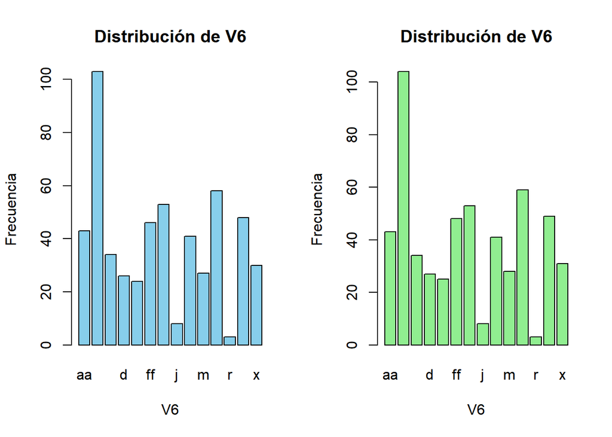

```r
#____________________V6_______________
frecuencias <- table(credit.Datos.Train$V6)
barplot(frecuencias,
        main = "Distribución de V6",
        xlab = "V6",
        ylab = "Frecuencia",
        col = "skyblue")

frecuencias <- table(credit.Datos.Train.imp$V6)
barplot(frecuencias,
        main = "Distribución de V6",
        xlab = "V6",
        ylab = "Frecuencia",
        col = "lightgreen")
```

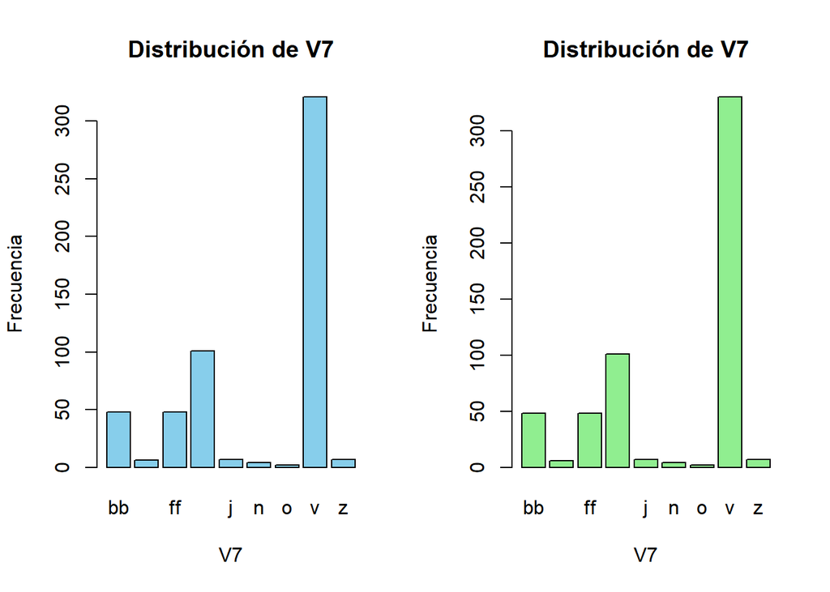

```r
#____________________V7_______________
frecuencias <- table(credit.Datos.Train$V7)
barplot(frecuencias,
        main = "Distribución de V7",
        xlab = "V7",
        ylab = "Frecuencia",
        col = "skyblue")

frecuencias <- table(credit.Datos.Train.imp$V7)
barplot(frecuencias,
        main = "Distribución de V7",
        xlab = "V7",
        ylab = "Frecuencia",
        col = "lightgreen")
```

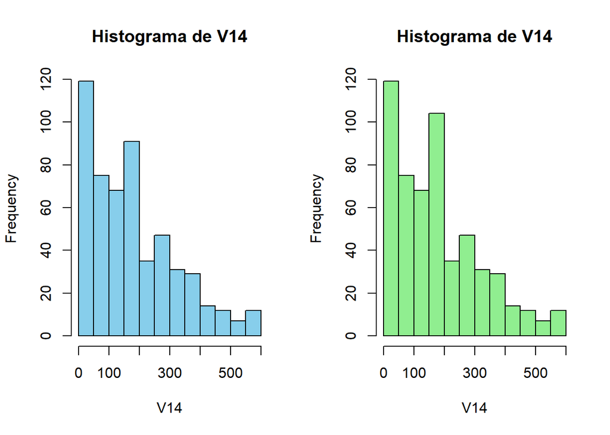

```r
#____________________V14_______________
hist(credit.Datos.Train$V14,
     main = "Histograma de V14",
     xlab = "V14",
     col = "skyblue")

hist(credit.Datos.Train.imp$V14,
     main = "Histograma de V14",
     xlab = "V14",
     col = "lightgreen")
```

En cuanto a la sustitución mediante estudio de correlaciones, podemos ver si hay alguna de la siguiente manera (lo hacemos con los datos sin imputar para justificar que no era necesario usarlo):

```r
# Solo las columnas numéricas
credit.Datos.numericas <- credit.Datos.Train[, sapply(credit.Datos.Train, is.numeric)]

matriz_correlacion <- cor(credit.Datos.numericas, use = "complete.obs")

print(matriz_correlacion)
```

```
##                        Edad      Deuda AnyosContratado  Solvencia         V14
## Edad             1.00000000  0.2285522      0.33280076  0.1778291 -0.09349217
## Deuda            0.22855222  1.0000000      0.24493606  0.2171899 -0.26448017
## AnyosContratado  0.33280076  0.2449361      1.00000000  0.3246872 -0.01841663
## Solvencia        0.17782905  0.2171899      0.32468718  1.0000000 -0.12410576
## V14             -0.09349217 -0.2644802     -0.01841663 -0.1241058  1.00000000
## V15              0.11198221  0.1462029      0.17696894  0.3934957 -0.05135915
##                         V15
## Edad             0.11198221
## Deuda            0.14620294
## AnyosContratado  0.17696894
## Solvencia        0.39349573
## V14             -0.05135915
## V15              1.00000000
```

Es evidente que no hay ninguna fuerte correlación entre variables, por tanto, hemos excluido esta opción de imputación. Al no haber correlación tampoco es interesante la sustitución de variables numéricas mediante clustering (knn).

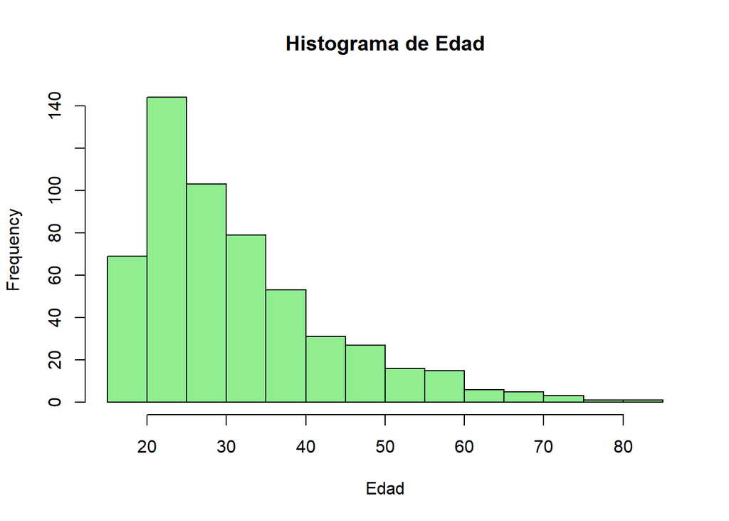

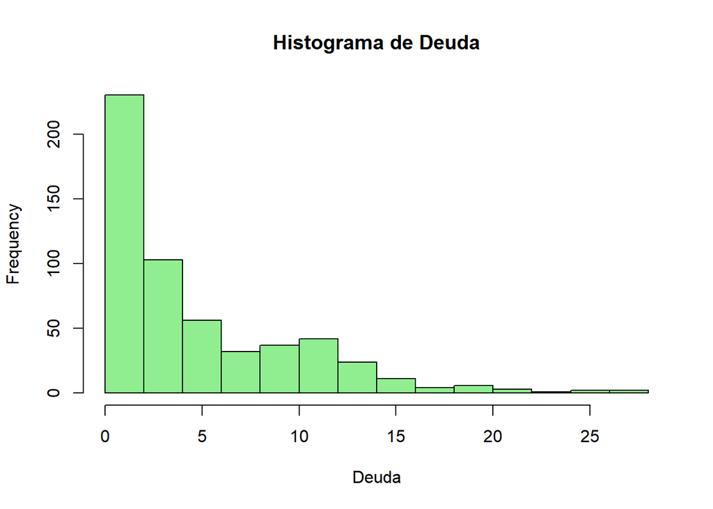

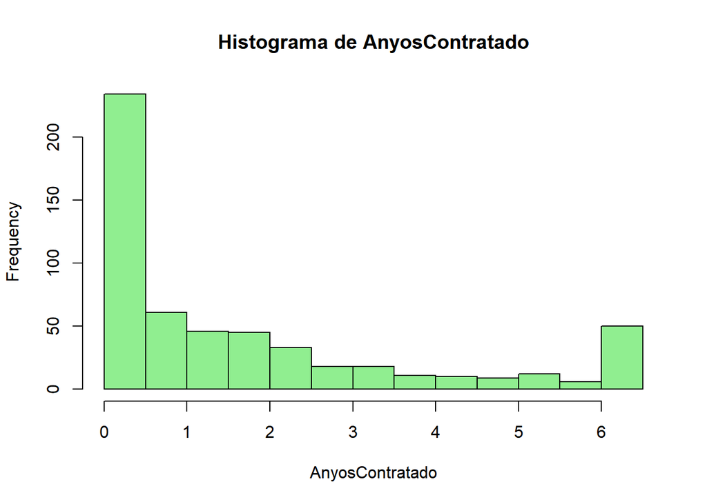

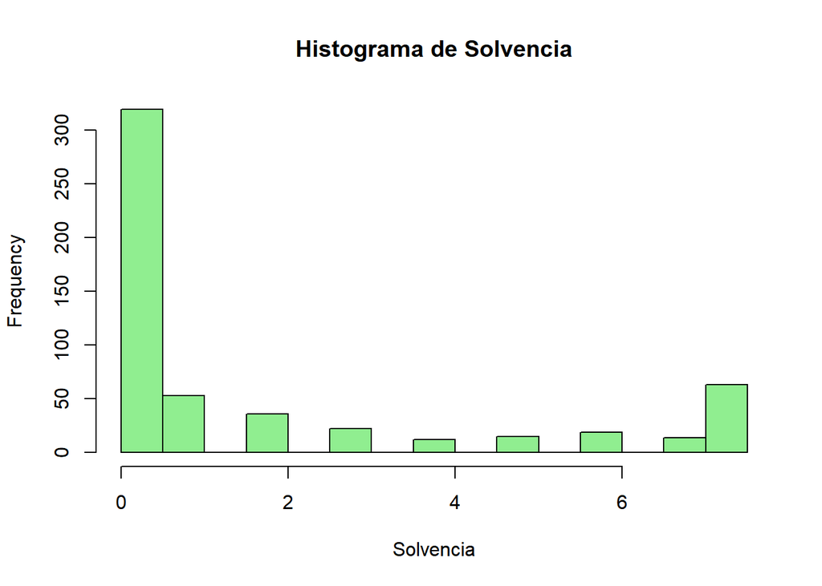

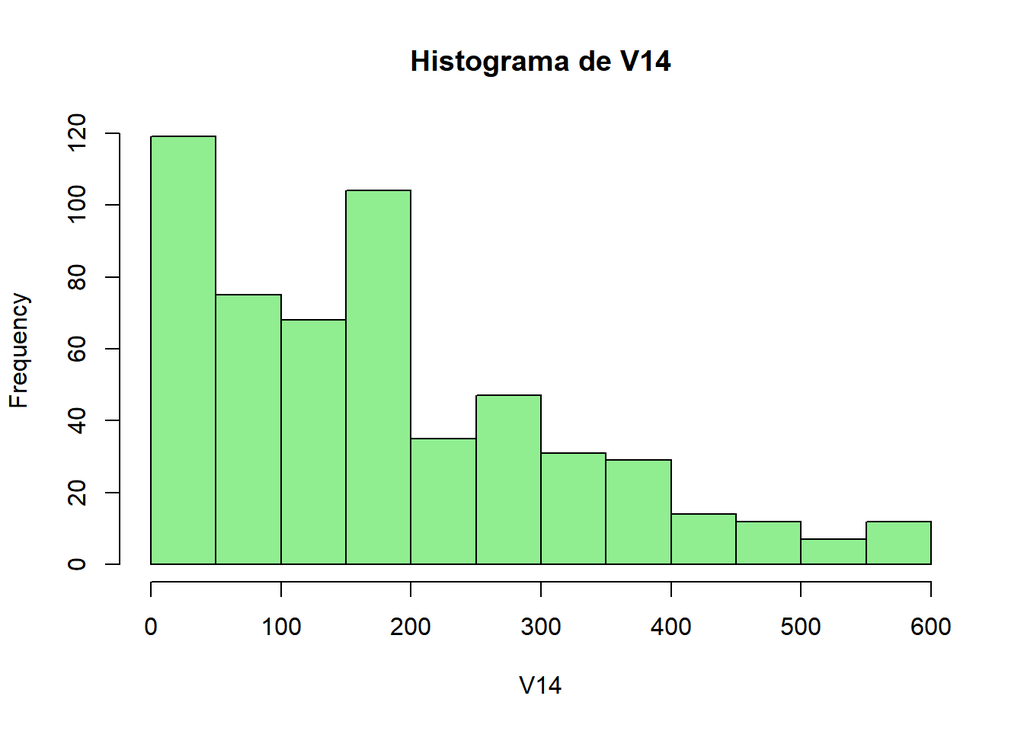

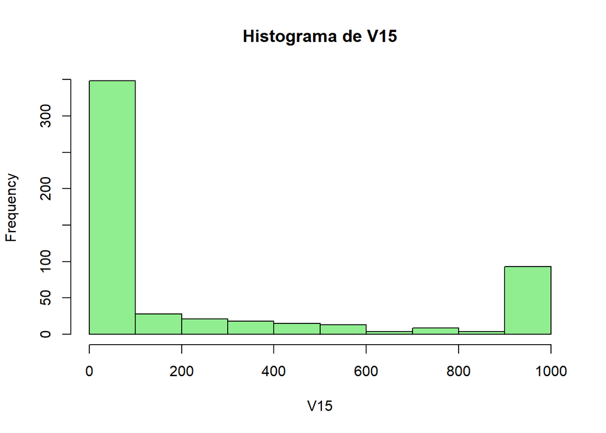

```r
gen_plots <- function() {

  credit.Datos.continuas <- credit.Datos.Train.imp[, sapply(credit.Datos.Train.imp, is.numeric)]

  for (name in colnames(credit.Datos.continuas)) {
    hist(credit.Datos.continuas[[name]],
         main = paste("Histograma de", name),
         xlab = name,
         col = "lightgreen")
  }
}

# Ejecutar la función
gen_plots()
```

En el caso en el que queramos quitar toda la imputación, comentar este código:

```r
credit.Datos.Test <- credit.Datos.Test.imp
credit.Datos.Train <- credit.Datos.Train.imp
```

# 5 Pre-procesado de datos (II): Eliminar predictores correlados o de poca Varianza

## 5.1 1. Eliminar variables con poca Varianza

Debemos de comprobar si la base de datos tiene columnas con poca varianza. Esto lo podemos comprobar con nearZero():

**Aclaración:** No tenemos en cuenta la última columna con valores {train, test} ya que no cuentan para el análisis.

```r
nearZeroVar(credit.Datos.Train[, 1:16])
```

```
## integer(0)
```

```r
nearZeroVar(credit.Datos.Test[, 1:16])
```

```
## integer(0)
```

Como vemos no hay ninguna columna que tenga varianza cercana a cero, lo que nos indica que los datos están ya bastante “limpios”.

## 5.2 2. Eliminar variables correladas:

Ya hemos justificado antes que no hay variables correladas, observando la matriz de correlación.

```r
#Dummys
credit.Data.To.Dummy <- rbind(credit.Datos.Train, credit.Datos.Test)
credit.Var.Salida <- c("V16")
credit.Var.Salida.Usada <- c("V16", "Origen")
credit.Var.Entrada.Usadas <- setdiff(names(credit.Data.To.Dummy),credit.Var.Salida.Usada)
credit.Var.Entrada.Dummys <- credit.Var.Entrada.Usadas
summary(credit.Data.To.Dummy)
```

```
##     Genero               Edad           Deuda        EstadoCivil
##  Length:690         Min.   :18.00   Min.   : 0.000   Length:690
##  Class :character   1st Qu.:22.67   1st Qu.: 1.000   Class :character
##  Mode  :character   Median :28.17   Median : 2.750   Mode  :character
##                     Mean   :31.57   Mean   : 4.759
##                     3rd Qu.:37.71   3rd Qu.: 7.207
##                     Max.   :80.25   Max.   :28.000
##       V5                 V6                 V7            AnyosContratado
##  Length:690         Length:690         Length:690         Min.   :0.000
##  Class :character   Class :character   Class :character   1st Qu.:0.165
##  Mode  :character   Mode  :character   Mode  :character   Median :1.000
##                                                           Mean   :1.786
##                                                           3rd Qu.:2.625
##                                                           Max.   :6.003
##       V9              Empleado           Solvencia         V12
##  Length:690         Length:690         Min.   :0.000   Length:690
##  Class :character   Class :character   1st Qu.:0.000   Class :character
##  Mode  :character   Mode  :character   Median :0.000   Mode  :character
##                                        Mean   :1.793
##                                        3rd Qu.:3.000
##                                        Max.   :7.500
##  composicionPoblacion      V14             V15             V16
##  Length:690           Min.   :  0.0   Min.   :   0.0   Length:690
##  Class :character     1st Qu.: 80.0   1st Qu.:   0.0   Class :character
##  Mode  :character     Median :160.0   Median :   5.0   Mode  :character
##                       Mean   :178.3   Mean   : 248.3
##                       3rd Qu.:272.0   3rd Qu.: 395.5
##                       Max.   :590.5   Max.   :1000.0
##     Origen
##  Length:690
##  Class :character
##  Mode  :character
##
##
##
```

```r
# También qué factores serán Ranked  (tienen un orden implícito o una jerarquía definida,
# pero no se consideran completamente ordinales en el sentido clásico)
credit.Ranked.Factors <- c("Genero", "EstadoCivil", "Empleado","composicionPoblacion", "V9", "V12")
# Se separan los factores ordenados (no hay que hacer Dummy)
credit.All.Factors<-names(credit.Data.To.Dummy[,credit.Var.Entrada.Usadas])[sapply(
  credit.Data.To.Dummy[,credit.Var.Entrada.Usadas], FUN=is.factor)]
credit.Ordered.Factors<-names(credit.Data.To.Dummy[,credit.Var.Entrada.Usadas])[sapply(
  credit.Data.To.Dummy[,credit.Var.Entrada.Usadas], FUN=is.ordered)]
# No hay ordenados
credit.Non.Ordered.Factors<-setdiff(credit.All.Factors,credit.Ordered.Factors)
credit.No.Ranked<-setdiff(credit.Non.Ordered.Factors,credit.Ranked.Factors)

# Se calculan las dummy de los ranked y no ranked
credit.Cols.Ranked <- NULL
if (length(credit.Ranked.Factors) > 0) {
  credit.Dummy.Ranked <- dummyVars(
    paste("~", paste(credit.Ranked.Factors, sep = "", collapse = " + "), collapse = ""),
    data = credit.Data.To.Dummy, fullRank = T)
  credit.Cols.Ranked <- data.frame(predict(credit.Dummy.Ranked,
                                           newdata = credit.Data.To.Dummy))
}
credit.Cols.No.Ranked <- NULL
if (length(credit.No.Ranked) > 0) {
  credit.Dummy.No.Ranked <- dummyVars(
    paste("~", paste(credit.No.Ranked, sep = "", collapse = " + "), collapse = ""),
    data = credit.Data.To.Dummy)
  credit.Cols.No.Ranked <- data.frame(predict(credit.Dummy.No.Ranked,
                                              newdata = credit.Data.To.Dummy))
}


credit.Cols.Salida <- data.frame(credit.Data.To.Dummy[, credit.Var.Salida.Usada])
names(credit.Cols.Salida) <- credit.Var.Salida.Usada

# Se eliminan de los datos originales todas las columnas a reemplazar
credit.Data.With.Dummy <- credit.Data.To.Dummy[, setdiff(names(credit.Data.To.Dummy),credit.Var.Salida)]

credit.Data.With.Dummy <- credit.Data.With.Dummy[, setdiff(names(credit.Data.With.Dummy),credit.No.Ranked)]

credit.Data.With.Dummy <- credit.Data.With.Dummy[, setdiff(names(credit.Data.With.Dummy), credit.Ranked.Factors)]

credit.Data.With.Dummy <- credit.Data.With.Dummy[, setdiff(names(credit.Data.With.Dummy), credit.Ordered.Factors)]

# Se añaden todas las columnas nuevas
if (!is.null(credit.Cols.Ranked))
  credit.Data.With.Dummy <- cbind(credit.Data.With.Dummy, credit.Cols.Ranked)
if (!is.null(credit.Cols.No.Ranked))
  credit.Data.With.Dummy <- cbind(credit.Data.With.Dummy, credit.Cols.No.Ranked)
credit.Data.With.Dummy <- cbind(credit.Data.With.Dummy, credit.Cols.Salida)
```

En caso de querer eliminar el paso de Dummy, podemos simplemente comentar el siguiente código:

```r
credit.Datos.Train <- credit.Data.With.Dummy[credit.Data.With.Dummy$Origen == "train", ]
credit.Datos.Test <- credit.Data.With.Dummy[credit.Data.With.Dummy$Origen == "test", ]
```

# 6 Pre-procesado de datos (III): Transformando y construyendo variables (Feature Engineering).

## 6.1 1. Sobre transformaciones de las variables de salida

No hay casos en los que a escala pueda dar errores de representación de los valores por la precisión de la representación. Y por temas de legibilidad ya hemos cambiado los valores de salida. Siendo el signo más y menos, aprobada y rechazada respectivamente.

## 6.2 2. Transformación de Variables

### 6.2.1 2.1. Escalado:

NORMALIZACIÓN CENTER SCALE

Mostramos los datos antes de hacer la normalización:

[figure not shown]

```r
credit.Datos.Todo <- rbind(credit.Datos.Train, credit.Datos.Test)
credit.Continuas <- credit.Datos.Todo[, sapply(credit.Datos.Todo, is.numeric)]
ggplot() +
  geom_density(aes(x = credit.Continuas$Edad, fill = "Edad"), alpha = 0.5) +
  geom_density(aes(x = credit.Continuas$Deuda, fill = "Deuda"), alpha = 0.5) +
  geom_density(aes(x = credit.Continuas$AnyosContratado, fill = "Años Contratado"), alpha = 0.5) +
  geom_density(aes(x = credit.Continuas$Solvencia, fill = "Solvencia"), alpha = 0.5) +
  geom_density(aes(x = credit.Continuas$V14, fill = "V14"), alpha = 0.5) +
  geom_density(aes(x = credit.Continuas$V15, fill = "V15"), alpha = 0.5) +
  labs(
    title = "Distribución de Variables Continuas (Density Plot)",
    x = "Valor",
    y = "Densidad"
  ) +
  scale_fill_manual(
    values = c("lightgreen", "lightblue", "lightcoral", "lightyellow", "lightpink", "lightgray"),
    name = "Variables",
    labels = c("Edad", "Deuda", "Años Contratado", "Solvencia", "V14", "V15")
  ) +
  theme_minimal() +
  xlim(-1, 100)
```

```r
theme(legend.title = element_blank())
```

```
## List of 1
##  $ legend.title: list()
##   ..- attr(*, "class")= chr [1:2] "element_blank" "element"
##  - attr(*, "class")= chr [1:2] "theme" "gg"
##  - attr(*, "complete")= logi FALSE
##  - attr(*, "validate")= logi TRUE
```

Hay que destacar que hemos limitado la x a 100, para poder visualizar el gráfico (de otra forma sería ilegible). Los datos llegarían hasta el 1000. Ahora vamos a normalizar y ver el gráfico de nuevo:

Anotar que las categóricas se quitan solas

## 6.3 COMENTO ESTE CODIGO PORQUE DA FALLOS Y QUIERO EL VER HTML COMPILADO

```r
# credit.Datos.Todo <- rbind(credit.Datos.Train, credit.Datos.Test)
#
# credit.Var.Salida.Usada <- c("V16")
# credit.Var.Entrada.Usadas <- setdiff(names(credit.Datos.Todo),credit.Var.Salida.Usada)
# credit.Var.Entrada.Escaladas <- credit.Var.Entrada.Usadas
#
# credit.preProc.CS.Mod<-preProcess(credit.Datos.Train[credit.Var.Entrada.Escaladas],method=c("center","scale"))
# credit.Datos.Train.Transf.CS<-predict(credit.preProc.CS.Mod,credit.Datos.Train)
# credit.Datos.Test.Transf.CS<-predict(credit.preProc.CS.Mod,credit.Datos.Test)
#
# VarToPlot<-credit.Var.Entrada.Escaladas
#
# d1<-densityplot(formula(paste("~",paste(VarToPlot,sep="",collapse =" + "),collapse="")),data=credit.Datos.Train,main="Variables sin Normalizar",plot.points=F)
#
# d2<-densityplot(formula(paste("~",paste(VarToPlot,sep="",collapse =" + "),collapse="")),data=credit.Datos.Train.Transf.CS, main="Variables Normalizadas",plot.points=F)
#
# # Gráficos en blanco y negro (mejor para imprimir)
# trellis.par.set(theme = standard.theme("pdf",color=FALSE))
# print(d1,position=c(0,0,0.5,1),more=T)
# print(d2,position=c(0.5,0,1,1))
# # Volvemos a gráficos normales
# trellis.par.set(theme = standard.theme("pdf"))
#
#
# credit.Datos.Train.Transf.CS <- credit.Datos.Train.Transf.CS  # Este es el dataset normalizado
#
# # Identificar las variables numéricas (continuas)
# credit.Vars.Continuas <- sapply(credit.Datos.Train.Transf.CS, is.numeric)
# credit.normalizadasCS <- credit.Datos.Train.Transf.CS[, credit.Vars.Continuas]

##############
# Crear el gráfico directamente
# ggplot(data = credit.normalizadasCS) +
#   geom_density(aes(x = Edad, fill = "Edad"), alpha = 0.5) +
#   geom_density(aes(x = Deuda, fill = "Deuda"), alpha = 0.5) +
#   geom_density(aes(x = AnyosContratado, fill = "Años Contratado"), alpha = 0.5) +
#   geom_density(aes(x = Solvencia, fill = "Solvencia"), alpha = 0.5) +
#   geom_density(aes(x = V14, fill = "V14"), alpha = 0.5) +
#   geom_density(aes(x = V15, fill = "V15"), alpha = 0.5) +
#   labs(
#     title = "Distribución de Variables Continuas (Density Plot)",
#     x = "Valor",
#     y = "Densidad"
#   ) +
#   scale_fill_manual(
#     values = c("lightgreen", "lightblue", "lightcoral", "lightyellow", "lightpink", "lightgray"),
#     name = "Variables",
#     labels = c("Edad", "Deuda", "Años Contratado", "Solvencia", "V14", "V15")
#   ) +
#   theme_minimal() +
#   theme(legend.title = element_blank())
```

En caso de no querer incluir la normalización center scale en nuestros datos, comentar esto:

## 6.4 COMENTO ESTE CODIGO PORQUE DA FALLOS Y QUIERO EL VER HTML COMPILADO

```r
# credit.Datos.Train <- credit.normalizadasCS[credit.normalizadasCS$Origen == "train", ]
# credit.Datos.Test <- credit.normalizadasCS[credit.normalizadasCS$Origen == "test", ]
```

RANGE:  
## COMENTO ESTE CODIGO PORQUE DA FALLOS Y QUIERO EL VER HTML COMPILADO

```r
# #Normalizacion Range [0,1]
# credit.preProc.Range.Mod<-preProcess(credit.Datos.Train[credit.Var.Entrada.Escaladas],
#                                   method="range")
# credit.Datos.Train.Transf.Range<-predict(credit.preProc.Range.Mod,credit.Datos.Train)
# credit.Datos.Test.Transf.Range<-predict(credit.preProc.Range.Mod,credit.Datos.Test)
#
# credit.Vars.Continuas <- sapply(credit.Datos.Train.Transf.Range, is.numeric)
# credit.normalizadasRange <- credit.Datos.Train.Transf.Range[, credit.Vars.Continuas]
#
# ##############
# # Crear el gráfico directamente
# ggplot() +
#   geom_density(aes(x = credit.normalizadasRange$Edad, fill = "Edad"), alpha = 0.5) +
#   geom_density(aes(x = credit.normalizadasRange$Deuda, fill = "Deuda"), alpha = 0.5) +
#   geom_density(aes(x = credit.normalizadasRange$AnyosContratado, fill = "Años Contratado"), alpha = 0.5) +
#   geom_density(aes(x = credit.normalizadasRange$Solvencia, fill = "Solvencia"), alpha = 0.5) +
#   geom_density(aes(x = credit.normalizadasRange$V14, fill = "V14"), alpha = 0.5) +
#   geom_density(aes(x = credit.normalizadasRange$V15, fill = "V15"), alpha = 0.5) +
#   labs(
#     title = "Distribución de Variables Continuas (Density Plot)",
#     x = "Valor",
#     y = "Densidad"
#   ) +
#   scale_fill_manual(
#     values = c("lightgreen", "lightblue", "lightcoral", "lightyellow", "lightpink", "lightgray"),
#     name = "Variables",
#     labels = c("Edad", "Deuda", "Años Contratado", "Solvencia", "V14", "V15")
#   ) +
#   theme_minimal() +
#   xlim(-1, 1)
# theme(legend.title = element_blank())
```

En caso de NO querer incluir esta normalización de tipo rango, comentar este código:

```r
#credit.Datos.Train <- credit.normalizadasRange[credit.normalizadasRange$Origen == "train", ]
#credit.Datos.Test <- credit.normalizadasRange[credit.normalizadasRange$Origen == "test", ]
```

PCA:

```r
#Eliminar previamente valores atipicos, muy sebsible
#Sobre los datos de entrenamiento IMPORTANTE
credit.Var.Entrada.Continuas <- which(sapply(credit.Datos.Train[, -ncol(credit.Datos.Train)], is.numeric))

credit.PreProc.Pca.Mod<-preProcess(credit.Datos.Train[credit.Var.Entrada.Continuas],method=c("pca"),thresh = 0.9)
credit.Datos.Train.Transf.PCA <- predict(credit.PreProc.Pca.Mod, credit.Datos.Train)
credit.Datos.Test.Transf.PCA <- predict(credit.PreProc.Pca.Mod, credit.Datos.Test)

print(credit.PreProc.Pca.Mod)
```

```
## Created from 553 samples and 14 variables
##
## Pre-processing:
##   - centered (14)
##   - ignored (0)
##   - principal component signal extraction (14)
##   - scaled (14)
##
## PCA needed 10 components to capture 90 percent of the variance
```

```r
summary(credit.Datos.Train.Transf.PCA)
```

```
##       V5                 V6                 V7               Origen
##  Length:553         Length:553         Length:553         Length:553
##  Class :character   Class :character   Class :character   Class :character
##  Mode  :character   Mode  :character   Mode  :character   Mode  :character
##
##
##
##      V16              Origen.1              PC1               PC2
##  Length:553         Length:553         Min.   :-3.7278   Min.   :-2.7020
##  Class :character   Class :character   1st Qu.:-1.3364   1st Qu.:-1.0121
##  Mode  :character   Mode  :character   Median :-0.2527   Median :-0.3891
##                                        Mean   : 0.0000   Mean   : 0.0000
##                                        3rd Qu.: 1.2269   3rd Qu.: 0.7194
##                                        Max.   : 4.8565   Max.   : 4.1598
##       PC3               PC4                PC5                PC6
##  Min.   :-3.9916   Min.   :-2.84339   Min.   :-2.26396   Min.   :-3.3166
##  1st Qu.:-0.8738   1st Qu.:-0.77786   1st Qu.:-0.63173   1st Qu.:-0.7039
##  Median : 0.1216   Median :-0.06007   Median : 0.03402   Median : 0.1097
##  Mean   : 0.0000   Mean   : 0.00000   Mean   : 0.00000   Mean   : 0.0000
##  3rd Qu.: 0.8385   3rd Qu.: 0.66765   3rd Qu.: 0.43113   3rd Qu.: 0.6417
##  Max.   : 3.1249   Max.   : 4.42305   Max.   : 6.75089   Max.   : 2.3280
##       PC7               PC8                PC9                PC10
##  Min.   :-1.8367   Min.   :-2.64419   Min.   :-5.01147   Min.   :-2.42315
##  1st Qu.:-0.6780   1st Qu.:-0.57067   1st Qu.:-0.55962   1st Qu.:-0.51994
##  Median :-0.2002   Median : 0.03114   Median : 0.05942   Median : 0.01868
##  Mean   : 0.0000   Mean   : 0.00000   Mean   : 0.00000   Mean   : 0.00000
##  3rd Qu.: 0.5331   3rd Qu.: 0.59776   3rd Qu.: 0.58994   3rd Qu.: 0.48210
##  Max.   : 4.7958   Max.   : 2.41905   Max.   : 2.22097   Max.   : 3.03264
```

```r
summary(credit.Datos.Test.Transf.PCA)
```

```
##       V5                 V6                 V7               Origen
##  Length:137         Length:137         Length:137         Length:137
##  Class :character   Class :character   Class :character   Class :character
##  Mode  :character   Mode  :character   Mode  :character   Mode  :character
##
##
##
##      V16              Origen.1              PC1                PC2
##  Length:137         Length:137         Min.   :-3.25394   Min.   :-1.8793
##  Class :character   Class :character   1st Qu.:-1.24981   1st Qu.:-0.9998
##  Mode  :character   Mode  :character   Median :-0.16137   Median :-0.2985
##                                        Mean   : 0.04065   Mean   : 0.1575
##                                        3rd Qu.: 1.20640   3rd Qu.: 1.6639
##                                        Max.   : 4.13472   Max.   : 3.7984
##       PC3                PC4                PC5                 PC6
##  Min.   :-3.21999   Min.   :-2.56622   Min.   :-2.264103   Min.   :-2.79079
##  1st Qu.:-0.89328   1st Qu.:-0.62920   1st Qu.:-0.660112   1st Qu.:-0.76074
##  Median :-0.04884   Median : 0.04965   Median :-0.006787   Median : 0.09267
##  Mean   :-0.14720   Mean   : 0.07381   Mean   :-0.099867   Mean   :-0.04975
##  3rd Qu.: 0.76523   3rd Qu.: 0.62575   3rd Qu.: 0.392961   3rd Qu.: 0.66899
##  Max.   : 2.10713   Max.   : 3.31929   Max.   : 1.690387   Max.   : 2.19926
##       PC7                PC8                PC9                PC10
##  Min.   :-1.50444   Min.   :-2.73818   Min.   :-2.48210   Min.   :-1.96958
##  1st Qu.:-0.51859   1st Qu.:-0.79384   1st Qu.:-0.44697   1st Qu.:-0.43846
##  Median :-0.01494   Median :-0.08916   Median : 0.15721   Median : 0.01060
##  Mean   : 0.07941   Mean   :-0.11209   Mean   : 0.06725   Mean   : 0.05293
##  3rd Qu.: 0.62285   3rd Qu.: 0.52987   3rd Qu.: 0.61386   3rd Qu.: 0.49140
##  Max.   : 2.43655   Max.   : 1.88915   Max.   : 1.89880   Max.   : 2.89827
```

En caso de NO querer incluir PCA, comentar el siguiente código:

```r
credit.Datos.Train <- credit.Datos.Train.Transf.PCA
credit.Datos.Test <- credit.Datos.Test.Transf.PCA
```

ICA:  
## COMENTO ESTE CODIGO PORQUE DA FALLOS Y QUIERO EL VER HTML COMPILADO

```r
# # IMPORTANTE LEER: EN MI CASO HE TENIDO QUE INSTALAR:
# #           sudo apt install liblapack-dev libblas-dev gfortran
#
# # Sobre credit (se calcula sobre train)
# library(fastICA)
# library(caret)
#
#
# credit.PreProc.Ica.Mod <- preProcess(credit.Datos.Train[credit.Var.Entrada.Continuas], method = c("ica"), n.comp = 2)
# credit.Datos.Train.Transf.ICA <- predict(credit.PreProc.Ica.Mod, credit.Datos.Train)
# credit.Datos.Test.Transf.ICA <- predict(credit.PreProc.Ica.Mod, credit.Datos.Test)
# print(credit.PreProc.Ica.Mod)
# summary(credit.Datos.Train.Transf.ICA)
# summary(credit.Datos.Test.Transf.ICA)
```

En caso de NO querer incluir ICA, comentar el siguiente código:

```r
#credit.Datos.Train <- credit.Datos.Train.Transf.ICA
#credit.Datos.Test <- credit.Datos.Test.Transf.ICA
```

# 7 Entrenamiento de modelos

lista de requisitos probados:

1. Imputación estándar
2. dummies
3. Normalización CENTER SCALE (NO ME DEJA)
4. PCA (NO ME DEJA AL NORMALIZAR)

## 7.1 GBM

## 7.2 COMENTO ESTE CODIGO PORQUE DA FALLOS Y QUIERO EL VER HTML COMPILADO

```r
# # Antes de nada:
#
# # Eliminar la última columna del conjunto de entrenamiento
# credit.Datos.Train <- credit.Datos.Train[, -ncol(credit.Datos.Train)]
#
# # Eliminar la última columna del conjunto de prueba
# credit.Datos.Test <- credit.Datos.Test[, -ncol(credit.Datos.Test)]
#
#
#
# # Definir las variables de entrada y salida
# credit.Var.Salida.Usada <- "V16"  # Cambiar según tu variable de salida
# credit.Vars.Entrada.Usadas <- setdiff(names(credit.Datos.Train), credit.Var.Salida.Usada)
#
# # Configurar el modelo GBM
# set.seed(1234)
# credit.modelo.gbm <- train(
#   credit.Datos.Train[credit.Vars.Entrada.Usadas], # Variables de entrada
#   credit.Datos.Train[[credit.Var.Salida.Usada]], # Variable de salida
#   method = "gbm",                                # Método GBM
#   trControl = trainControl(method = "cv", number = 5), # Validación cruzada
#   verbose = FALSE                                # Evitar logs innecesarios
# )
#
# # Ver los detalles del modelo entrenado
# print(credit.modelo.gbm)
#
# # Predecir en el conjunto de prueba
# credit.Pred.Test <- predict(credit.modelo.gbm, credit.Datos.Test)
#
# # Evaluar el rendimiento en el conjunto de prueba
# confusionMatrix(credit.Pred.Test, credit.Datos.Test[[credit.Var.Salida.Usada]])
```

Vemos procentaje:

```r
# # Realizar predicciones en el conjunto de prueba
# predicciones_test <- predict(credit.modelo.gbm, credit.Datos.Test)
#
# # Generar la matriz de confusión
# matriz_confusion <- confusionMatrix(predicciones_test, credit.Datos.Test[[credit.Var.Salida.Usada]])
#
# # Extraer el porcentaje de acierto
# porcentaje_acierto <- matriz_confusion$overall["Accuracy"] * 100
#
# # Mostrar el porcentaje de acierto
# print(paste("Porcentaje de acierto:", round(porcentaje_acierto, 2), "%"))
```

## 7.3 Random Forest

Vamos a entreenar este modelo, pero antes vamos a ver los hiperparametros que tiene para ello usamos el siguiente comando:

```r
modelLookup(("rf"))
```

|  | model | parameter | label | forReg | forClass | probModel |
| --- | --- | --- | --- | --- | --- | --- |
| 1 | rf | mtry | #Randomly Selected Predictors | TRUE | TRUE | TRUE |

Como en random forest no permite datos NA hay que imputarlas o eliminarlas:

```r
# 1. Cargar librerías necesarias
library(caret)      # Para entrenar y validar el modelo
library(randomForest) # Para Random Forest (usado internamente por caret)


credit.trainIdx <- readRDS("credit.trainIdx.rds")
credit.Datos.Train <- credit[credit.trainIdx,]
credit.Datos.Test <- credit[-credit.trainIdx,]


credit.Datos.Train.SinNA <- na.omit(credit.Datos.Train)


any(is.na(credit.Datos.Train.SinNA))
```

```
## [1] FALSE
```

```r
# 2. Verificar las estructuras de las bases de datos
# Asegúrate de que la variable respuesta esté presente y sea un factor (para clasificación)
str(credit.Datos.Train.SinNA)
```

```
## 'data.frame':    516 obs. of  16 variables:
##  $ V1 : Factor w/ 2 levels "a","b": 2 2 2 2 2 1 2 2 1 2 ...
##  $ V2 : num  30.8 27.8 20.2 32.1 33.2 ...
##  $ V3 : num  0 1.54 5.62 4 1.04 ...
##  $ V4 : Factor w/ 4 levels "l","u","y","t": 2 2 2 2 2 2 3 3 2 3 ...
##  $ V5 : Factor w/ 3 levels "g","gg","p": 1 1 1 1 1 1 3 3 1 3 ...
##  $ V6 : Factor w/ 14 levels "aa","c","cc",..: 13 13 13 10 12 3 9 13 9 9 ...
##  $ V7 : Factor w/ 9 levels "bb","dd","ff",..: 8 8 8 8 4 8 4 8 8 8 ...
##  $ V8 : num  1.25 3.75 1.71 2.5 6.5 ...
##  $ V9 : Factor w/ 2 levels "f","t": 2 2 2 2 2 2 2 2 2 2 ...
##  $ V10: Factor w/ 2 levels "f","t": 2 2 1 1 1 1 1 1 1 2 ...
##  $ V11: int  1 5 0 0 0 0 0 0 0 10 ...
##  $ V12: Factor w/ 2 levels "f","t": 1 2 1 2 2 1 1 2 2 2 ...
##  $ V13: Factor w/ 3 levels "g","p","s": 1 1 3 1 1 1 1 1 1 1 ...
##  $ V14: int  202 100 120 360 164 80 180 52 0 320 ...
##  $ V15: int  0 3 0 0 31285 1349 314 1442 0 0 ...
##  $ V16: Factor w/ 2 levels "rechazada","aprobada": 2 2 2 2 2 2 2 2 2 2 ...
##  - attr(*, "na.action")= 'omit' Named int [1:37] 53 63 65 70 74 157 159 189 194 198 ...
##   ..- attr(*, "names")= chr [1:37] "72" "84" "87" "93" ...
```

```r
str(credit.Datos.Test)
```

```
## 'data.frame':    137 obs. of  16 variables:
##  $ V1 : Factor w/ 2 levels "a","b": 1 1 2 2 2 1 1 2 2 1 ...
##  $ V2 : num  58.7 24.5 22.1 29.9 48.1 ...
##  $ V3 : num  4.46 0.5 0.83 1.83 6.04 ...
##  $ V4 : Factor w/ 4 levels "l","u","y","t": 2 2 2 2 2 2 2 2 2 2 ...
##  $ V5 : Factor w/ 3 levels "g","gg","p": 1 1 1 1 1 1 1 1 1 1 ...
##  $ V6 : Factor w/ 14 levels "aa","c","cc",..: 11 11 2 2 9 11 11 2 2 11 ...
##  $ V7 : Factor w/ 9 levels "bb","dd","ff",..: 4 4 4 4 8 8 8 8 8 8 ...
##  $ V8 : num  3.04 1.5 2.16 4.33 0.04 ...
##  $ V9 : Factor w/ 2 levels "f","t": 2 2 1 2 1 2 2 2 2 2 ...
##  $ V10: Factor w/ 2 levels "f","t": 2 1 1 1 1 2 2 2 1 2 ...
##  $ V11: int  6 0 0 0 0 7 10 17 0 3 ...
##  $ V12: Factor w/ 2 levels "f","t": 1 1 2 1 1 2 1 1 1 2 ...
##  $ V13: Factor w/ 3 levels "g","p","s": 1 1 1 1 1 1 1 1 3 1 ...
##  $ V14: int  43 280 128 260 0 0 120 200 300 145 ...
##  $ V15: int  560 824 0 200 2690 0 245 1208 0 0 ...
##  $ V16: Factor w/ 2 levels "rechazada","aprobada": 2 2 2 2 2 2 2 2 2 2 ...
```

```r
# 3. Definir variables predictoras y la variable objetivo
# Cambia "VariableObjetivo" por el nombre real de tu variable de salida
var_objetivo <- "V16"
vars_predictoras <- setdiff(names(credit.Datos.Train.SinNA), var_objetivo)

# 4. Asegurarse de que la variable objetivo sea un factor
credit.Datos.Train.SinNA[[var_objetivo]] <- as.factor(credit.Datos.Train.SinNA[[var_objetivo]])
#credit.Datos.Test[[var_objetivo]] <- as.factor(credit.Datos.Test[[var_objetivo]])

# 5. Configuración del control para validación cruzada
control_rf <- trainControl(
  method = "cv",               # Validación cruzada
  number = 5,                  # Número de folds
  verboseIter = TRUE,          # Mostrar progreso
  classProbs = TRUE,           # Calcular probabilidades de clase (si aplica)
  summaryFunction = twoClassSummary # Métricas adicionales como ROC (para clasificación binaria)
)

# 6. Definir el grid de hiperparámetros a probar
# Ajusta `mtry` al número de predictores en tus datos
tune_grid_rf <- expand.grid(
  mtry = seq(2, length(vars_predictoras), by = 2) # Rango de mtry a explorar
)

# 7. Entrenar el modelo Random Forest
set.seed(123) # Para reproducibilidad
modelo_rf <- train(
  x = credit.Datos.Train.SinNA[vars_predictoras], # Variables predictoras
  y = credit.Datos.Train.SinNA[[var_objetivo]],   # Variable objetivo
  method = "rf",                            # Random Forest
  trControl = control_rf,                   # Configuración de validación
  tuneGrid = tune_grid_rf,                  # Grid de hiperparámetros
  ntree = 500                               # Número de árboles
)
# 8. Resumen del modelo entrenado
print(modelo_rf)
```

```
## Random Forest
##
## 516 samples
##  15 predictor
##   2 classes: 'rechazada', 'aprobada'
##
## No pre-processing
## Resampling: Cross-Validated (5 fold)
## Summary of sample sizes: 412, 413, 413, 413, 413
## Resampling results across tuning parameters:
##
##   mtry  ROC        Sens       Spec
##    2    0.9338539  0.8861529  0.8765957
##    4    0.9340745  0.8718672  0.8893617
##    6    0.9352724  0.8647243  0.8936170
##    8    0.9337326  0.8611529  0.8893617
##   10    0.9333000  0.8575815  0.8893617
##   12    0.9346924  0.8611529  0.8808511
##   14    0.9334027  0.8611529  0.8808511
##
## ROC was used to select the optimal model using the largest value.
## The final value used for the model was mtry = 6.
```

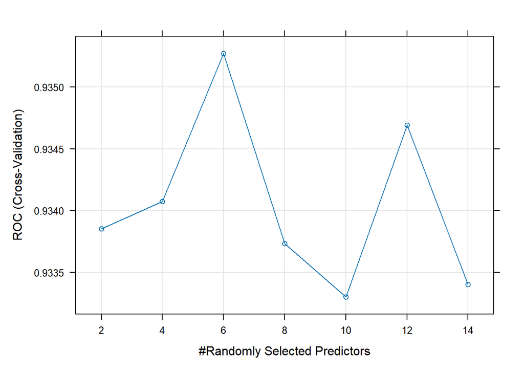

```r
plot(modelo_rf)
```

```r
# 9. Guardar el modelo entrenado
saveRDS(modelo_rf, "modelo_rf.rds")

# 10. Evaluación del modelo en el conjunto de prueba
# Predicción en el conjunto de prueba
predicciones <- predict(modelo_rf, newdata = credit.Datos.Test[vars_predictoras])

# Generar matriz de confusión
confusionMatrix(
  data = predicciones,
  reference = credit.Datos.Test[[var_objetivo]],
  positive = "aprobada" # Cambia esto por la clase objetivo positiva
)
```

```
## Confusion Matrix and Statistics
##
##            Reference
## Prediction  rechazada aprobada
##   rechazada        59        8
##   aprobada         17       53
##
##                Accuracy : 0.8175
##                  95% CI : (0.7425, 0.8783)
##     No Information Rate : 0.5547
##     P-Value [Acc > NIR] : 8.032e-11
##
##                   Kappa : 0.6359
##
##  Mcnemar's Test P-Value : 0.1096
##
##             Sensitivity : 0.8689
##             Specificity : 0.7763
##          Pos Pred Value : 0.7571
##          Neg Pred Value : 0.8806
##              Prevalence : 0.4453
##          Detection Rate : 0.3869
##    Detection Prevalence : 0.5109
##       Balanced Accuracy : 0.8226
##
##        'Positive' Class : aprobada
##
```

## 7.4 Redes neuronales

Pasamos ahroa a entrenar el modelo de redes neuronales, primero vemis los posibkes hiperparametros disponbles que tiene:

```r
modelLookup(("nnet"))
```

|  | model | parameter | label | forReg | forClass | probModel |
| --- | --- | --- | --- | --- | --- | --- |
| 1 | nnet | size | #Hidden Units | TRUE | TRUE | TRUE |
| 2 | nnet | decay | Weight Decay | TRUE | TRUE | TRUE |

```r
# 1. Cargar librerías necesarias
library(caret) # Para entrenar el modelo
library(nnet)  # Paquete para redes neuronales

# 2. Verificar las estructuras de las bases de datos
# Define el nombre de la variable objetivo y las variables predictoras
var_objetivo <- "V16" # Cambia esto por tu variable de salida
vars_predictoras <- setdiff(names(credit.Datos.Train), var_objetivo)


# 3. Configuración del control para validación cruzada
control_nnet <- trainControl(
  method = "cv",               # Validación cruzada
  number = 5,                  # Número de folds
  verboseIter = TRUE,          # Mostrar progreso
  classProbs = TRUE,           # Probabilidades de clase (para clasificación)
  summaryFunction = twoClassSummary # Métricas adicionales como ROC
)

# 4. Definir el grid de hiperparámetros
tune_grid_nnet <- expand.grid(
  size = c(1, 3, 5, 7),  # Número de nodos en la capa oculta
  decay = c(0, 0.01, 0.1) # Parámetro de regularización (previene sobreajuste)
)

# 5. Entrenar el modelo con nnet
set.seed(123) # Para reproducibilidad
modelo_nnet <- train(
  x = credit.Datos.Train[vars_predictoras], # Variables predictoras
  y = credit.Datos.Train[[var_objetivo]],   # Variable objetivo
  method = "nnet",                          # Especificamos nnet
  trControl = control_nnet,                 # Configuración de validación
  tuneGrid = tune_grid_nnet,                # Grid de hiperparámetros
  trace = FALSE,                            # Evita imprimir mensajes internos de nnet
  maxit = 200                               # Número máximo de iteraciones
)
# 6. Resumen del modelo entrenado
print(modelo_nnet)
```

```
## Neural Network
##
## 553 samples
##  15 predictor
##   2 classes: 'rechazada', 'aprobada'
##
## No pre-processing
## Resampling: Cross-Validated (5 fold)
## Summary of sample sizes: 443, 442, 442, 442, 443
## Resampling results across tuning parameters:
##
##   size  decay  ROC        Sens       Spec
##   1     0.00   0.7078321  0.9138558  0.4797217
##   1     0.01   0.7690854  0.8981749  0.5738398
##   1     0.10   0.7999319  0.8021708  0.7263722
##   3     0.00   0.6885582  0.8326240  0.4892769
##   3     0.01   0.8709948  0.8274017  0.8074352
##   3     0.10   0.9032094  0.8503774  0.7859736
##   5     0.00   0.8451373  0.8126345  0.7827089
##   5     0.01   0.8859546  0.8165549  0.7825316
##   5     0.10   0.8777013  0.8363289  0.7655990
##   7     0.00   0.7683215  0.8480004  0.5965850
##   7     0.01   0.8891537  0.8396069  0.8159497
##   7     0.10   0.9038064  0.8754101  0.7956676
##
## ROC was used to select the optimal model using the largest value.
## The final values used for the model were size = 7 and decay = 0.1.
```

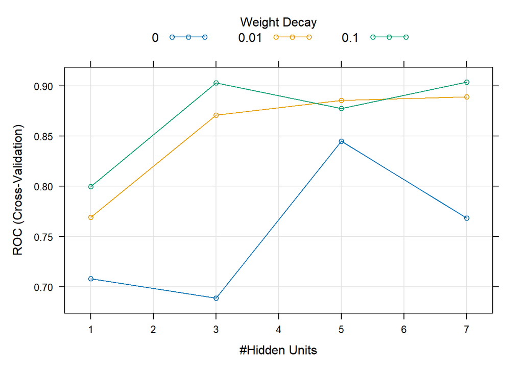

```r
plot(modelo_nnet)
```

```r
# 7. Evaluar el modelo en el conjunto de prueba
# Predicción en el conjunto de prueba
predicciones_nnet <- predict(modelo_nnet, newdata = credit.Datos.Test[vars_predictoras])

# Matriz de confusión
confusionMatrix(
  data = predicciones_nnet,
  reference = credit.Datos.Test[[var_objetivo]],
  positive = "aprobada" # Cambia esto por el nivel positivo correcto
)
```

```
## Confusion Matrix and Statistics
##
##            Reference
## Prediction  rechazada aprobada
##   rechazada        62        9
##   aprobada         14       52
##
##                Accuracy : 0.8321
##                  95% CI : (0.7588, 0.8905)
##     No Information Rate : 0.5547
##     P-Value [Acc > NIR] : 5.609e-12
##
##                   Kappa : 0.6629
##
##  Mcnemar's Test P-Value : 0.4042
##
##             Sensitivity : 0.8525
##             Specificity : 0.8158
##          Pos Pred Value : 0.7879
##          Neg Pred Value : 0.8732
##              Prevalence : 0.4453
##          Detection Rate : 0.3796
##    Detection Prevalence : 0.4818
##       Balanced Accuracy : 0.8341
##
##        'Positive' Class : aprobada
##
```